# Estimating Corn Supply & Demand

[figure not shown]

[figure not shown]

[figure not shown]

[figure not shown]

# Introduction

#### Lab Requirements

- Download and use the [WASDE.csv file](https://purdue.brightspace.com/content/enforced/1209888-wl.202520.AGR.33300.001/WASDE.csv?ou=1209888)

#### Background

In this lab, we will make use of the World Agricultural Supply and Demand Estimates (WASDE) published by the U.S. Department of Agriculture (USDA). The purpose of this exercise is to analyze the supply and demand for corn and learn how to estimate demand curves. The skills developed in this lab are readily transferable to other commodities. We will also introduce some basic time-series concepts that we will build on in the next lab.

**Sources used in this lab:**

1. Good, D. and S. Irwin. “The Relationship between Stocks-to-Use and Corn Prices Revisited.” farmdoc daily (5):65, Department of Agricultural and Consumer Economics, University of Illinois at Urbana-Champaign, April 9, 2015.
2. Mallory, Mindy L. 2018. *Price Analysis: A Fundamental Approach to the Study of Commodity Prices*. Available at http://mindymallory.com/PriceAnalysis/index.html

# Setup

### Getting Started

#### Step 1 – Install and Load Packages

In this lab we will use the **ggplot2** package to generate visually appealing graphs and the **gridExtra** package to display multiple ggplot graphs together.

```
# Install (only if not already installed)
#install 'ggplot2'
#install 'gridExtra'

# Load packages
#ggplot2
#gridExtra
```

#### Step 2 – Data Import

Download the `WASDE.csv` file and save it to a convenient location on your computer.

Set your working directory to the folder where you saved the data. This will make it easy to load and save files without specifying the full path each time.

```
# Set working directory (edit this path for your computer)
setwd("C:/Users/student/OneDrive - purdue.edu/GRAD 505/CornLab")
getwd()  # Check your working directory
```

Now import the WASDE data using the `read.csv()` command. Since your working directory is set, you only need the filename.

```
# Import WASDE data
WASDE <-

# Explore the dataset
head()
str()
```

The data set contains U.S. corn supply and demand (use) for the period 1973–2019, including U.S. corn production, beginning stocks (carryover), imports, domestic use, and exports in millions of bushels.

# Exploring Trends

#### Step 3 – Visualize Corn Price, Demand, and Supply Trends Over Time

Using `ggplot()`, we will graph the trends in corn prices, use (demand), and supply over time. The `ggplot()` function appends different graph options with the `+` sign. `ggplot()` has many features which you are encouraged to learn about online and incorporate into your graphs.

**Example:**  
The general pattern for making a time series line plot with `ggplot2` is:

```
ggplot(data = your_data, aes(x = time_variable, y = value_variable)) +
  geom_line(color = "your_color") +
  ggtitle("Your Plot Title") +
  labs(y = "Y Axis Label", x = "X Axis Label")
```

Now, let’s apply this to our corn data:

```
# Plot corn prices, total corn supply, and total corn demand over time
g_price <-

g_demand <-

g_supply <-

grid.arrange(g_price, g_demand, g_supply, nrow=3)
```

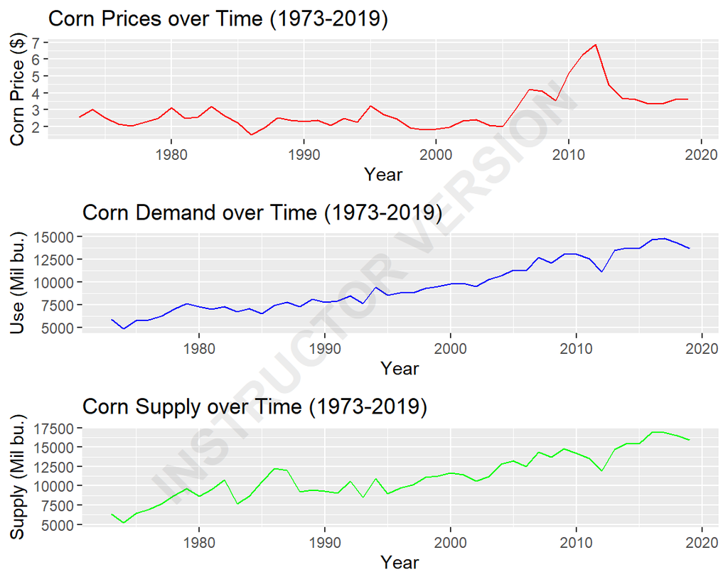

**Tips for making effective time series plots:**

- Change the color in `geom_line()` to distinguish between variables.
- Use `ggtitle()` and `labs()` to make your plots clear and informative.
- Add `geom_point()` to show individual data points if desired.
- Try using `theme_minimal()` or other themes for a different look.
- Save your plot with `ggsave("filename.png")`

**Task:**  
Save the graph in your working directory. You will use this for your module homework assignment.

**Question:**  
What do you notice about the trends in corn prices?  
How about demand and supply?  
What was happening around 2006 to cause the price of corn to rise so rapidly during that period?  
What can you say from these graphs about the relative sizes of demand and supply over time? Does one tend to outstrip the other?

**Challenge:**  
As you’ve seen, creating similar plots for different variables can lead to repetitive code. To make your workflow more efficient and your code easier to maintain, **try writing a function that generates these time series plots for any variable in your dataset**.

- Your function should take arguments for the dataset, the variable to plot on the y-axis, the line color, the plot title, and the y-axis label.
- Inside the function, use `ggplot()` to create and return the plot.
- Once you’ve written your function, use it to recreate the corn price, demand, and supply plots above.

Need help getting started?  
Review the Understanding Functions in R section at the end of this document for examples and tips on how to write your own functions.

#### Step 4 – Relating Price to Corn Stock-to-Use Ratio

A common measure agricultural economists use to analyze commodities is the ratio of ending stocks (whatever supply of the commodity is left over at the end of the year) to total use (demand) of the commodity. Simply put, the stock-to-use ratio (SUR) tells us how much corn is left over as a share of all the corn consumed during the year. Mathematically, the stock-to-use ratio is calculated as follows:

$$\begin{align*}
SUR_t &= \frac{\text{Total Supply}_t - \text{Total
Use}_t}{\text{Total Use}_t} &= \frac{\text{Total
Supply}_t}{\text{Total Use}_t} - 1
\end{align*}$$

where the subscript $t$ denotes the year. SUR is useful because it measures both supply and demand at a given point in time. An increase in corn demand (holding supply constant) will lower the SUR while an increase in supply (holding demand constant) will raise the SUR.

Create a new variable called `SUR` in your WASDE data frame using the above formula and generate a scatterplot to visualize the relationship between corn prices and SUR. Include a linear regression line in the scatterplot.

To calculate the SUR for each year using your `WASDE` data frame:

```
# Create a new variable for stock-to-use ratio and create a scatterplot of corn prices on stock-to-use ratio
WASDE$SUR <-
```

Using `ggplot()`, we can visualize the relationship between two variables and add a regression line to see the trend. The `geom_point()` function creates the scatterplot, and `geom_smooth(method = lm)` adds a linear regression line.

**Example:**  
The general pattern for making a scatterplot with a regression line in `ggplot2` is:

```
ggplot(data = your_data, aes(x = x_variable, y = y_variable)) +
  geom_point(shape = 1) +
  geom_smooth(method = lm, color = "your_color") +
  ggtitle("Your Plot Title") +
  labs(y = "Y Axis Label", x = "X Axis Label")
```

Apply this to our corn data:

```
# Plot corn price vs. stock-to-use ratio with a regression line
ggplot(data = WASDE, aes(x = SUR, y = corn_price)) +
```

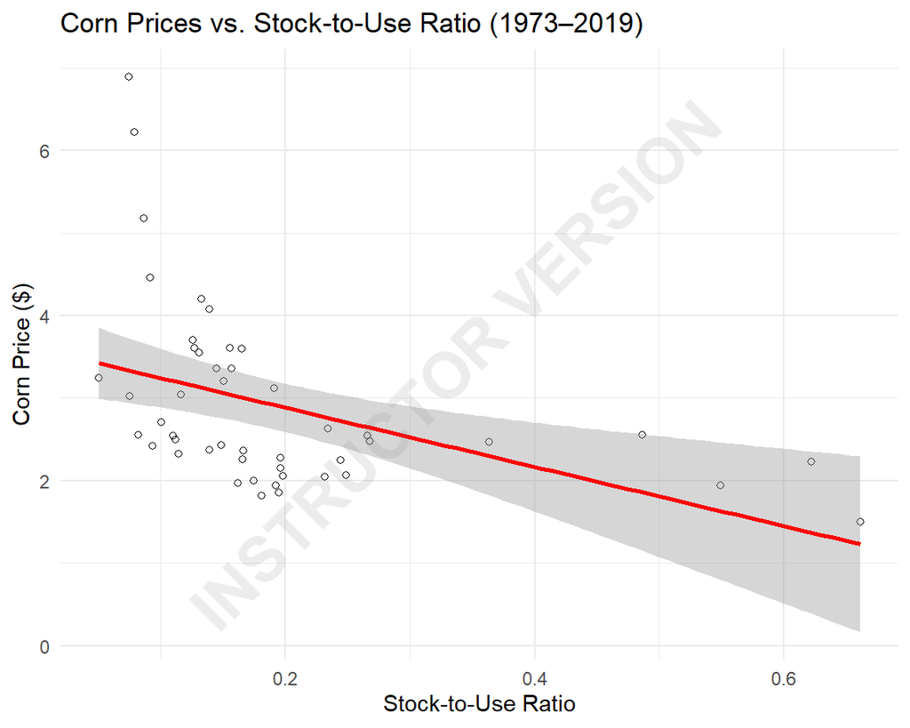

**Tips:**

- Change the `color` in `geom_smooth()` to customize the regression line.
- Adjust `shape` in `geom_point()` for different marker styles.
- Use `ggtitle()` and `labs()` to make your plot clear and informative.
- Try adding `theme_minimal()` or other themes for a different look.
- Save your plot with `ggsave("filename.png")` if you want to use it in reports or presentations.

**Task:**  
Save this graph in your working directory for later use.

**Question:**  
Does a linear regression line do a good job of fitting the underlying relationship between prices and SUR?

# Linear Regression Analysis

#### Step 5 - Linear Regression and Diagnostics

Let’s formally estimate the regression line shown in the scatterplot. The regression equation is expressed as:

$$\text{Corn Price}_t = \alpha + \beta \cdot \text{SUR}_t + \epsilon_t$$

#### Estimating the Regression Model

We use the `lm()` command to run the regression and the `summary()` command to print the results.

The `lm()` function in R fits a **linear regression model** to your data.  
The basic format is:

```r
lm(response_variable ~ predictor_variable, data = your_data)
```

For example, to model `y` as a function of `x` in a data frame called `my_data`:

```r
lm(y ~ x, data = my_data)
```

This will estimate the relationship between `x` and `y` by fitting a straight line to the data.

**Instructions:**

1. Replace `____` with the correct variable names and dataset
2. Use `SUR` as the predictor and `corn_price` as the response
3. Run both lines to see your regression results

```
# Estimate linear regression model (FILL IN THE BLANKS)
reg1 <- lm(____ ~ ____, data = ____)
summary(____)  # Add your model object here
```

**Task:**  
Copy and paste the regression output into an Excel table and format it in a presentable way. Include:

- Regression coefficients
- Standard errors
- R-squared value
- Number of observations

**Question:**  
According to our linear model, what is the effect of a one-unit increase in the SUR on corn prices?

**Tip:**  
As an alternative to copying results into Excel, use the `gtsummary` package to create a formatted regression results table directly in R. This will display the regression coefficients, standard errors, R-squared, and number of observations in a clean, publication-ready format.

Try running the following code after fitting your model:

```r
library(gtsummary)
tbl_regression(reg1, intercept = TRUE) %>%
  add_glance_source_note(include = c(r.squared, nobs))
```

| **Characteristic** | **Beta** | **95% CI** | **p-value** |
| --- | --- | --- | --- |
| (Intercept) | 3.6 | 3.1, 4.1 | <0.001 |
| SUR | -3.6 | -5.8, -1.4 | 0.002 |

Abbreviation: CI = Confidence Interval  
R² = 0.194; No. Obs. = 47

This approach is reproducible and professional!

#### Calculating Price Elasticity

To better interpret this effect in percentage terms, we can calculate the price **elasticity** of corn with respect to the SUR. Elasticity helps us understand how responsive the price of corn is to changes in supply and demand conditions captured by the SUR.

$$\text{Elasticity} = \frac{d\,\text{Corn Price}}{d\,\text{SUR}} \times
\frac{\text{SUR}}{\text{Corn Price}} = \hat{\beta} \times
\frac{\text{SUR}}{\text{Corn Price}}$$

Where: - $\hat{\beta}$ = Estimated coefficient on SUR from regression - $\text{SUR}$ = Average SUR in sample - $\text{Corn Price}$ = Average corn price in sample

You can use the `mean()` function to calculate averages for price and SUR

```
# Calculate averages
mean_sur <- mean(WASDE$SUR)
mean_price <- mean(WASDE$corn_price)
```

**Question:**  
How responsive (elastic) is the price of corn to changes in corn supply and demand?

#### Residual Analysis

Let’s examine the residual errors — the differences between the actual values and the model’s predictions — from the linear regression. We will use the `resid()` command to collect these error terms. Calculate summary statistics and plot a histogram of the errors.

Note: Use the `summary()` and `hist()` commands to inspect the regression errors

```
# Summary statistics of residuals
summary(resid(reg1))

# Histogram of residuals
hist(resid(reg1),
     main = "Histogram of Linear Regression Errors",
     xlab = "Linear Model Residuals")
```

**Question:**  
What do you notice about the distribution? Does this indicate a good model fit?

#### Residuals vs. SUR Plot

**Task:** Complete the code below to generate a scatterplot of the linear regression errors (residuals) against the stock-to-use ratio (SUR).

```
# Scatterplot of errors vs SUR
ggplot(data=WASDE, aes(x=SUR, y=resid(reg1))) +
```

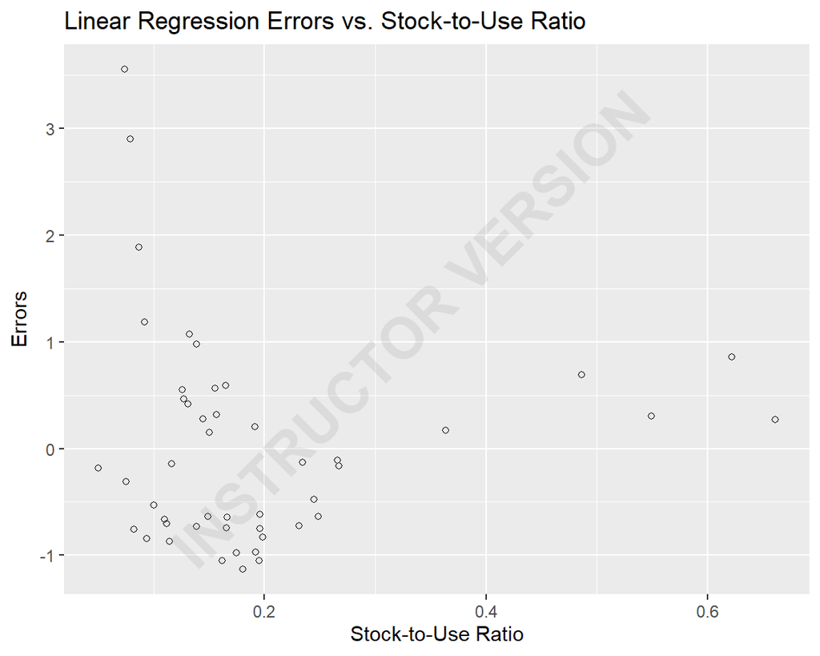

**Question:**  
Is there a relationship between the error terms and SUR? What does this imply about model fit?

# Non-linear Regression and Diagnostics

#### Step 6 - Non-linear Regression and Diagnostics

From the scatterplot, we observe that the relationship between corn price and SUR resembles an inverse relationship. We will estimate:

$$\text{Corn Price}_t = \alpha + \beta \cdot
\left(\frac{1}{\text{SUR}_t}\right) + \epsilon_t$$

#### Estimating the Inverse SUR Model

First, create the inverse of the stock-to-use ratio variable then regress corn prices on the inverse SUR.

```
# Create the inverse of stock-to-use ratio, run the regression, and examine the error terms
WASDE$SUR_Inv <- 1 / WASDE$SUR
reg2 <- lm(corn_price ~ SUR_Inv, data=WASDE)

summary(reg2)
```

**Task:** Use the `gtsummary` package to create a professional regression results table:

```r
library(gtsummary)
```

This approach is reproducible and professional!

#### Elasticity Calculation (Non-linear Model)

Because we are estimating a different model, we cannot readily compare the coefficients from this non-linear model to the earlier linear model. Instead, compute the elasticity between price and SUR based on the non-linear model (at the sample average of price and SUR), and compare to the elasticity derived from the linear model. Remember, the elasticity formula will differ from the linear model (see below).

$$\text{Elasticity} = \frac{d \text{Corn Price}}{d\text{SUR}} \times
\frac{\overline{\text{SUR}}}{\overline{\text{Corn Price}}} =
\frac{-\hat{\beta}}{(\overline{\text{SUR}})^2} \times
\frac{\overline{\text{SUR}}}{\overline{\text{Corn Price}}} =
\frac{-\hat{\beta}}{\overline{\text{SUR}} \times \overline{\text{Corn
Price}}}$$

**Question:**  
- How does this elasticity compare to the linear model?  
- What does this imply about the relationship?

#### Residual Diagnostics (Non-linear Model)

Run the same error diagnostics that you did for the linear regression

```
# Residual analysis
summary(resid(reg2))
hist(resid(reg2), main="Histogram of Non-linear Regression Errors", xlab="Non-linear Model Residuals")

# Residuals vs SUR plot
ggplot(data=WASDE, aes(x=SUR, y=resid(reg2))) +
  geom_point(shape=1) +
  ggtitle("Non-linear Regression Errors vs. Stock-to-Use Ratio") +
  labs(y="Errors", x="Stock-to-Use Ratio")
```

**Question:**  
- How has the error distribution changed compared to the linear model??  
- Is there still a relationship between residuals and SUR?

# Time-Split Analysis

#### Step 7 - Estimating separate demand curves for different time periods

Return to our scatterplot of corn prices on the SUR. Let’s break the data up into two time periods: 1973-2005 and 2006-2019. Using `ggplot()`, we can visualize how the relationship between price and SUR changed between time periods.

First we will need to create a character variable denoting the two time periods with the `ifelse()` command, then we will create a numeric dummy variable equal to one during the 2006-2019 period.

```
# Create a character variable denoting the two time periods, create a dummy variable for the post-2006 period, graph a scatterplot of price on SUR with unique colors and regression lines for each period
WASDE$period <- ifelse(WASDE$year >= 2006, "2006-2019", "1973-2005")
WASDE$P2006 <- as.numeric(WASDE$year >= 2006)

ggplot(data=WASDE, aes(x=SUR, y=corn_price, color=period)) +
  geom_point(shape=1) +
  geom_smooth(method=lm, se=FALSE) +
  ggtitle("Corn Prices vs. Stock-to-Use Ratio (1973–2019)") +
  labs(y="Corn Price ($)", x="Stock-to-Use Ratio")
```

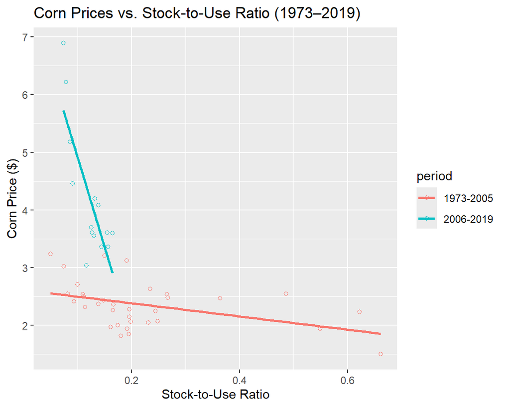

**Task:**  
Save the graph for later use.

**Questions:**  
- What do you notice about the price-SUR relationship between the two time periods?  
- We can use the dummy variable we created above to estimate both demand curves within the following regression equation

We can use the dummy variable we created above to estimate both demand curves within the following regression equation:

$$\text{Corn Price}_t = \alpha + \beta \cdot \text{SUR}_t + \delta \cdot
\text{P2006}_t + \gamma \cdot (\text{P2006}_t \times \text{SUR}_t) +
\epsilon_t$$

```
# Run a linear regression with time period specific
reg3 <- lm(corn_price ~ SUR + P2006 + SUR:P2006, data=WASDE)

summary(reg3)
```

**Question:**  
Compare the overall fit of the model to the previous two regressions. Is there an improvement in the adjusted R-squared?

# Auto-Correlation Check

#### Step 8 - Check for auto-correlation/serial correlation

From the time series graph you made earlier, you can see that corn prices appear related over time, that is, they are likely lag dependent. Failing to account for this lag dependency means the residual errors will suffer from “auto-correlation” or “serial correlation” which can bias the estimated relationship between prices and supply/demand. We will explore this concept in much more detail in the next lab but for now, let’s do a quick check for auto-correlation in the errors.

```
# Collect the residuals from the last regression, create a time series of the errors with a one-year lag of the error, then regress the error terms on the lagged error terms
error <- ts(resid(reg3), start=1973, end=2019, frequency=1)   # the ts() function tells R to set the errors as a time-series
lag_error <- lag(error, -1)                                   # the lag() function creates a one-period lag of the error term
error <- cbind(error, lag_error)                              # cbind() binds the specified vectors together as columns to create a new data frame

reg4 <- lm(error ~ lag_error, data=error)

summary(reg4)
```

**Question:**  
Looking at the coefficient on the lagged error term, is there evidence for auto-correlation?

We will explore solutions to auto-correlation in the next lab when we delve deeper into time series analysis.

# Understanding Functions in R

#### What is a Function?

A **function** in R is a reusable block of code that performs a specific task. Functions help you avoid repeating code, make your scripts easier to read, and allow you to update logic in one place.

R has many built-in functions (like `mean()`, `sum()`, `plot()`), but you can also create your own.

#### Why Use Functions?

- **Avoid repetition:** Write code once, use it many times.
- **Clarity:** Functions make your code easier to understand.
- **Maintainability:** Update logic in one place instead of many.

#### How to Write a Function in R

The basic structure of a function is:

```
my_function <- function(argument1, argument2, ...) {
  # Code to run
  result <- argument1 + argument2
  return(result)
}
```

- `my_function` is the name you give your function.
- `argument1`, `argument2`, … are inputs (also called parameters).
- The code inside the `{}` is what the function does.
- The `return()` statement gives back the result.

#### Example: A Simple Function

Suppose you want a function to add two numbers:

```
add_numbers <- function(a, b) {
  sum <- a + b
  return(sum)
}

# Usage
add_numbers(2, 3)
# 5
```

#### Example: A Plotting Function

Here’s how you might turn your corn trend plots into a function, so you don’t repeat code:

```
plot_corn_trend <- function(data, yvar, color, title, ylab) {
  ggplot(data = data, aes_string(x = "year", y = yvar)) +
    geom_line(color = color) +
    ggtitle(title) +
    labs(y = ylab, x = "Year")
}


# Usage
plot_corn_trend(WASDE, "corn_price", "red", "Corn Prices over Time", "Corn Price ($)")
```